# The R Markdown a11y theme

Alison Hill  
11/11/2020

## Exploration

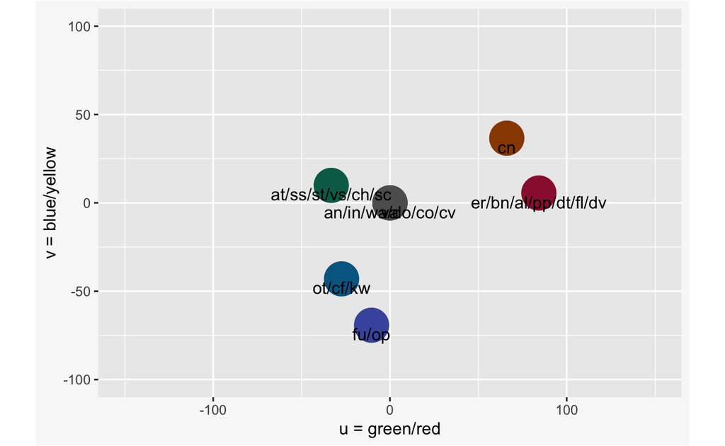

```
#a11y <- read_theme("https://github.com/rstudio/distill/raw/master/inst/rmarkdown/templates/distill_article/resources/a11y.theme")
a11y <- read_theme("a11y_v5.theme")

#a11y <- read_theme("a11y_v3.theme")

bg <- "#f8f8f8"
col <- a11y %>%
  group_by(fg) %>%
  summarise(abbr = paste(abbr, collapse = "/"), .groups = "drop") %>%
  filter(!is.na(fg)) %>%
  mutate(contrast = contrast_ratio(fg, bg))

col %>% plot_uv()
```

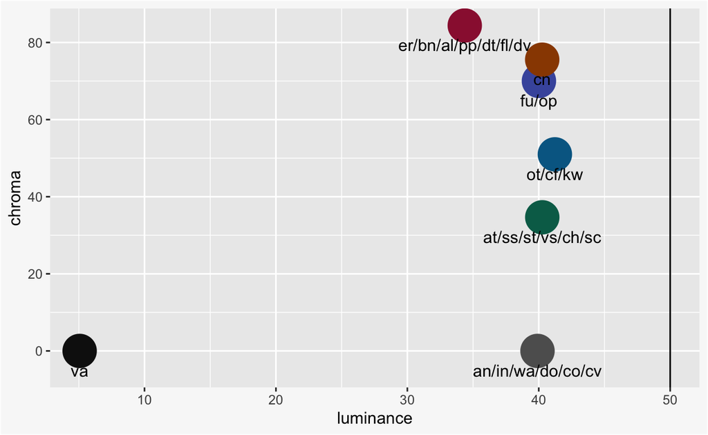

```
col %>% plot_cl()
```

```
col %>%
  arrange(contrast)
```

```
# A tibble: 7 x 3
  fg      abbr                 contrast
  <chr>   <chr>                   <dbl>
1 #006893 ot/cf/kw                 5.81
2 #006C57 at/ss/st/vs/ch/sc        6.02
3 #994800 cn                       6.03
4 #4758AB fu/op                    6.08
5 #5E5E5E an/in/wa/do/co/cv        6.11
6 #9b1d3d er/bn/al/pp/dt/fl/dv     7.50
7 #111111 va                      17.8
```

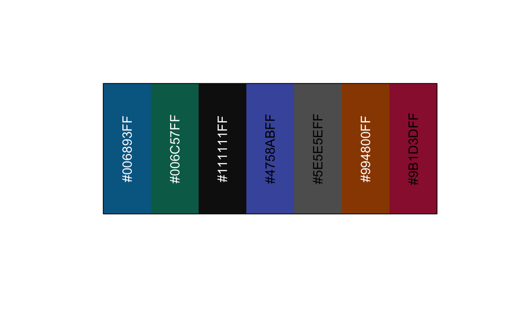

```
plot(prismatic::color(col$fg), labels = TRUE)
```

## Consolidate colors -> `col2`

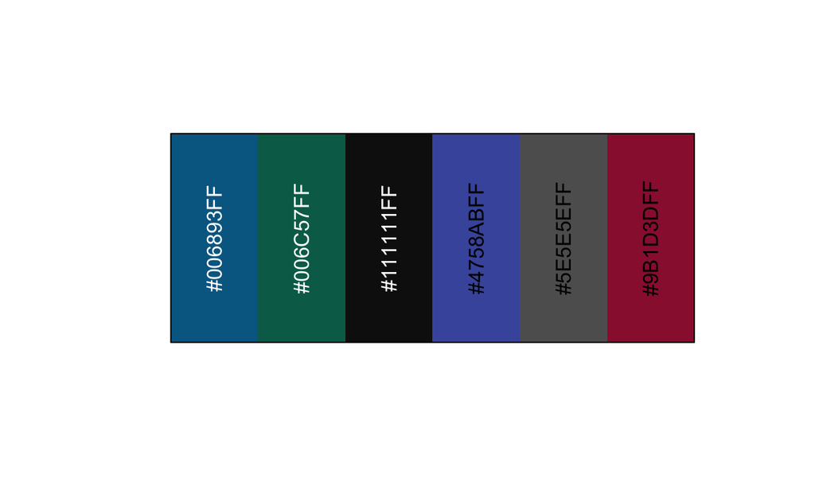

```
col2 <- col %>%
  filter(!abbr %in% c("op", "pp", "do", "cn", "ss", "at")) %>%
  mutate(fg_before2 = fg) %>%
  mutate(fg = ifelse(abbr == "er/al", "#d91e18", fg)) %>%
  mutate(contrast = contrast_ratio(fg, bg))

plot(prismatic::color(col2$fg), labels = TRUE)
```

## Problems now:

   ```
   col2 %>% filter(contrast < 4.5)
   ```

   ```
   # A tibble: 0 x 4
   # … with 4 variables: fg <chr>, abbr <chr>, contrast <dbl>,
   #   fg_before2 <chr>
   ```

## Adjust lightness -> `col3`

Stabilize lightness of colors - this means that none of the hex values match the original a11y hex colors anymore

```
col2 %>% filter(contrast < 4.5)
```

```
# A tibble: 0 x 4
# … with 4 variables: fg <chr>, abbr <chr>, contrast <dbl>,
#   fg_before2 <chr>
```

```
col3 <- col2 %>%
  mutate(
    fg_before3 = fg,
    fg = modify_hcl(fg, l = 40),
    contrast = contrast_ratio(fg, bg)
  )

col3 %>% pull(contrast) %>% sort() %>% round(1)
```

```
[1] 6.1 6.1 6.1 6.1 6.1 6.1
```

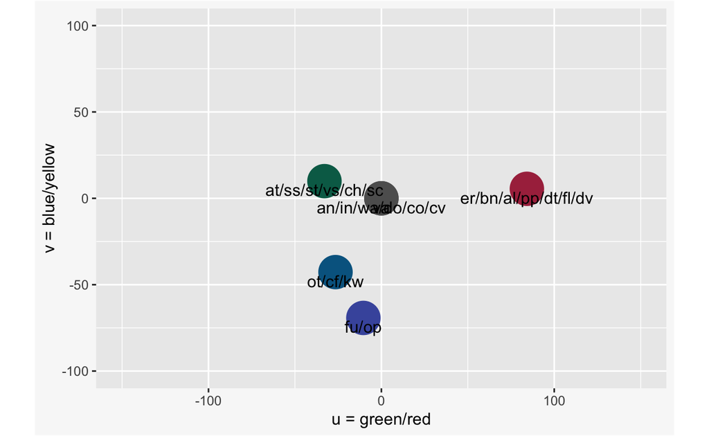

```
col3 %>% plot_uv()
```

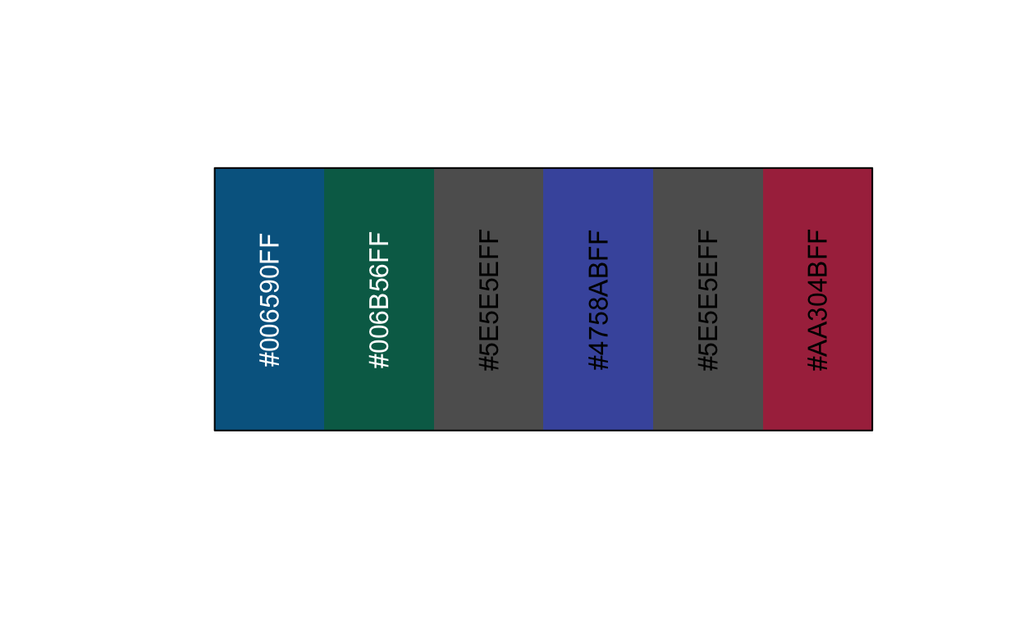

```
plot(prismatic::color(col3$fg), labels = TRUE)
```

## Make colors more distinct -> `col4`

aka questioning all the decisions thus far

1. `va` is too close to `fu/op`
   - make `fu/op` more negative on `v` channel? (done, -> `#4452C4`)
   - move `va` more positive on `u` channel?
2. make colours further apart - e.g. switch `bn/fl/dv` with `dt` (done)

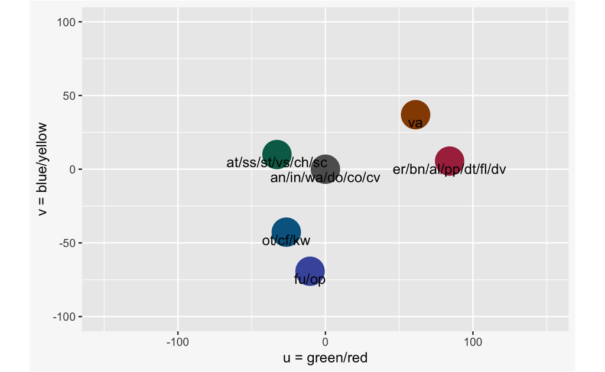

```
keepers <- c("bn/fl/dv", "ot/cf/kw")
col4 <- col3 %>%
  # save old fg
  mutate(fg_before4 = fg) %>%
  # replace the grey
  mutate(fg = ifelse(abbr == "an/in/wa/co/cv",
                     "#5E5E5E",
                     fg)) %>%
  # replace the red
  mutate(fg = ifelse(abbr == "er/al",
                     "#BD1600",
                     fg)) %>%
  # replace the green
  mutate(fg = ifelse(abbr == "st/vs/ch/sc",
                     "#006E4C",
                     fg)) %>%
  # replace the cobalt
  mutate(fg = ifelse(abbr == "fu",
                     "#4452C4",
                     fg)) %>%
  # switch `bn/fl/dv` with `dt`
  mutate(fg = ifelse(abbr == "bn/fl/dv", "#954A00", fg)) %>%
  mutate(fg = ifelse(abbr == "dt", "#B12458", fg)) %>%
  # replace va
  mutate(
    fg = ifelse(abbr == "va",
                modify_hcl(fg, h = 290), fg),
    fg = ifelse(abbr == "va",
                set_channel(fg, "u", 50, space = "Luv"), fg)
    #fg = ifelse(abbr == "va",
                #set_channel(fg, "v", -75, space = "Luv"), fg)
  ) %>%
  # lighten again
  mutate(
    fg = ifelse(!(abbr %in% keepers),
                modify_hcl(fg, l = 40),
                fg),
    contrast = contrast_ratio(fg, bg)
  ) %>%
  # last switcheroo
  mutate(fg = ifelse(abbr == "bn/fl/dv", "#9D2E93", fg)) %>%
  mutate(fg = ifelse(abbr == "va", "#954A00", fg))

col4 %>% plot_uv()
```

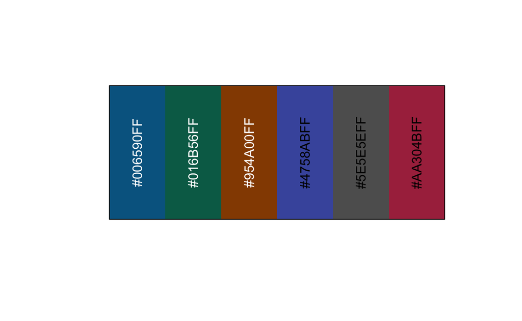

```
plot(prismatic::color(col4$fg), labels = TRUE)
```

- feels like need to choose between those last 3 colors- all too close #BC1500 -> #B12458
- also feels like lightness correction overcorrects for chelsea gem and deep cerulean, would rather keep those as fg_before4 vals just make sure the contrast is optimal
- can combine keyword with fu/op? #4452C4 -> #006893

## Check in

with those changes, here is where I think I am

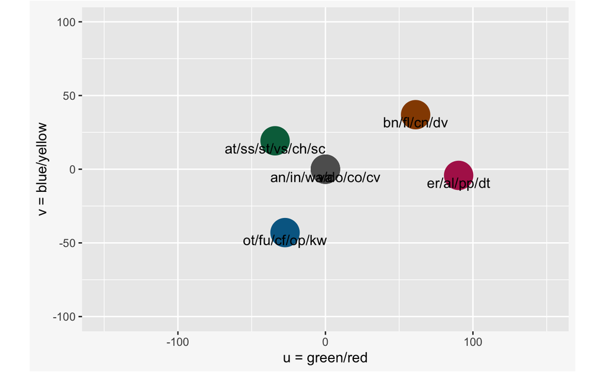

```
a11y_v2 <- read_theme("a11y_v2.theme")
bg <- "#f8f8f8"
col_v2 <- a11y_v2 %>%
  group_by(fg) %>%
  summarise(abbr = paste(abbr, collapse = "/"), .groups = "drop") %>%
  filter(!is.na(fg)) %>%
  mutate(contrast = contrast_ratio(fg, bg))

col_v2 %>% plot_uv()
```

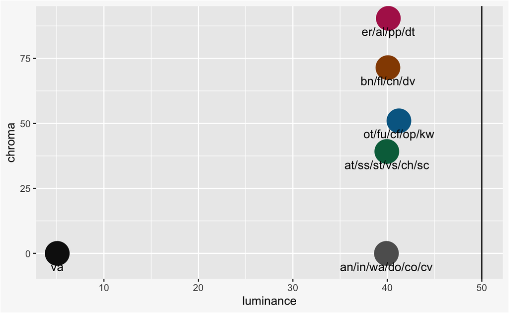

```
col_v2 %>% plot_cl()
```

```
col_v2 %>%
  arrange(contrast)
```

```
# A tibble: 6 x 3
  fg      abbr              contrast
  <chr>   <chr>                <dbl>
1 #006893 ot/fu/cf/op/kw        5.81
2 #B12458 er/al/pp/dt           6.06
3 #954A00 bn/fl/cn/dv           6.07
4 #006C4A at/ss/st/vs/ch/sc     6.10
5 #5E5E5E an/in/wa/do/co/cv     6.11
6 #111111 va                   17.8
```

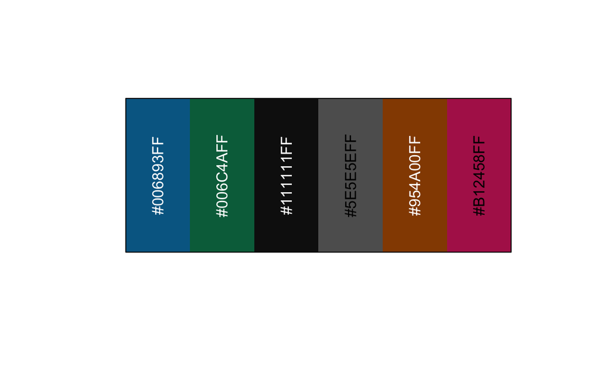

```
plot(prismatic::color(col_v2$fg), labels = TRUE)
```

Compare them

```
library(waldo)
compare(col4, col_v2)
```

```
`old` is length 6
`new` is length 3

    names(old)   | names(new)
[1] "fg"         | "fg"       [1]
[2] "abbr"       | "abbr"     [2]
[3] "contrast"   | "contrast" [3]
[4] "fg_before2" -
[5] "fg_before3" -
[6] "fg_before4" -

    old$fg    | new$fg
[1] "#006590" - "#006893" [1]
[2] "#016B56" - "#006C4A" [2]
[3] "#954A00" - "#111111" [3]
[4] "#4758AB" -
[5] "#5E5E5E" | "#5E5E5E" [4]
[6] "#AA304B" - "#954A00" [5]
              - "#B12458" [6]

    old$abbr               | new$abbr
[1] "ot/cf/kw"             - "ot/fu/cf/op/kw"    [1]
[2] "at/ss/st/vs/ch/sc"    | "at/ss/st/vs/ch/sc" [2]
[3] "va"                   | "va"                [3]
[4] "fu/op"                -
[5] "an/in/wa/do/co/cv"    | "an/in/wa/do/co/cv" [4]
[6] "er/bn/al/pp/dt/fl/dv" - "bn/fl/cn/dv"       [5]
                           - "er/al/pp/dt"       [6]

`old$contrast`: 6.06 6.11 6.10  6.08 6.11 6.12
`new$contrast`: 5.81      6.10 17.78 6.11 6.07 6.06

`old$fg_before2` is a character vector ('#006893', '#006C57', '#111111', '#4758AB', '#5E5E5E', ...)
`new$fg_before2` is absent

`old$fg_before3` is a character vector ('#006893', '#006C57', '#111111', '#4758AB', '#5E5E5E', ...)
`new$fg_before3` is absent

`old$fg_before4` is a character vector ('#006590', '#006B56', '#5E5E5E', '#4758AB', '#5E5E5E', ...)
`new$fg_before4` is absent
```

# ———————————————————-

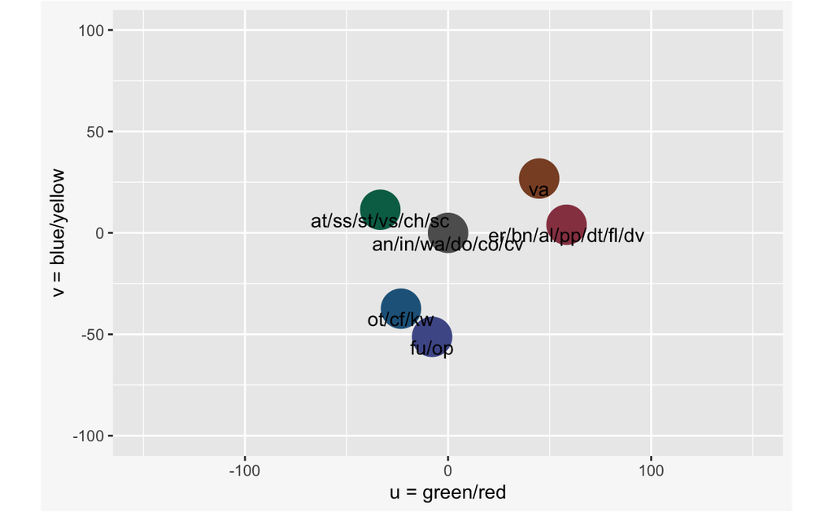

```
blend <- function(x, y, delta) {
  x * delta + y * (1 - delta)
}

col5 <- col4 %>%
  mutate(
    fg_before5 = fg,
    fg = modify_hcl(fg,
                    c = ifelse(c < 1, c, blend(c, 40, 0.4))
                    )
    )
col5 %>% plot_uv()
```

```
col5
```

```
# A tibble: 6 x 7
  fg     abbr     contrast fg_before2 fg_before3 fg_before4 fg_before5
  <chr>  <chr>       <dbl> <chr>      <chr>      <chr>      <chr>
1 #2364… ot/cf/kw     6.06 #006893    #006893    #006590    #006590
2 #006C… at/ss/s…     6.11 #006C57    #006C57    #006B56    #016B56
3 #8A4F… va           6.10 #111111    #111111    #5E5E5E    #954A00
4 #4F5A… fu/op        6.08 #4758AB    #4758AB    #4758AB    #4758AB
5 #5E5E… an/in/w…     6.11 #5E5E5E    #5E5E5E    #5E5E5E    #5E5E5E
6 #9842… er/bn/a…     6.12 #9b1d3d    #9b1d3d    #AA304B    #AA304B
```

# Colour blindness - experiment

# ——————————————————–

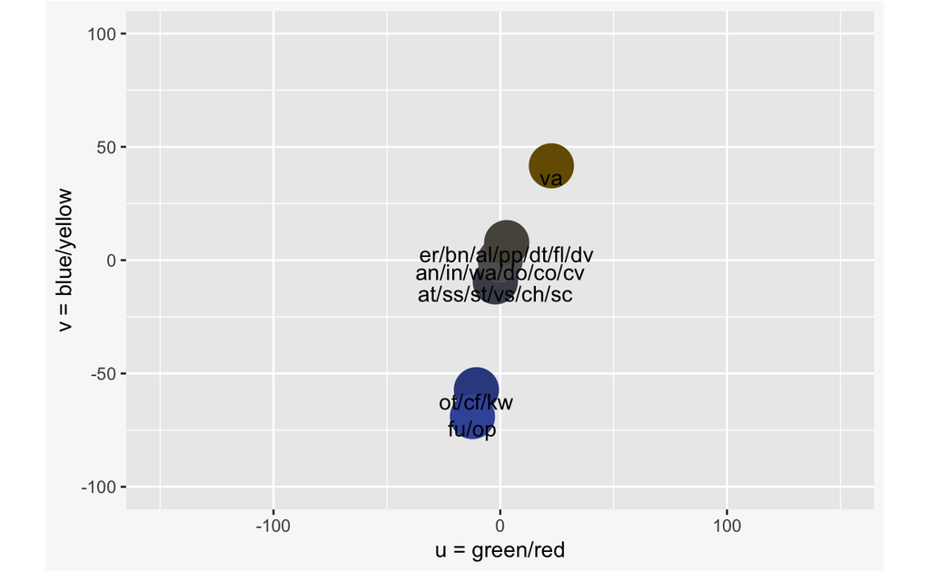

```
col4 %>%
  mutate(fg = prismatic::clr_deutan(fg)) %>%
  plot_uv()
```

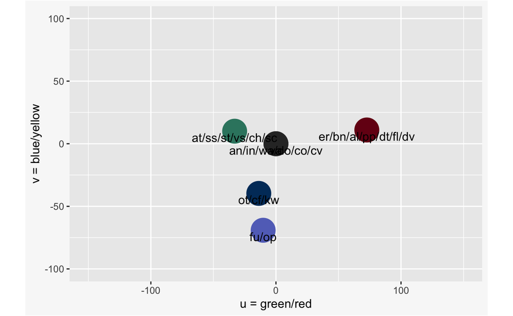

```
# Alternate between lighter and dark between adjacent hues
# Not very effective
col4 <- col3 %>%
  mutate(hcl(fg)) %>%
  arrange(h) %>%
  mutate(fg = modify_hcl(fg, l = rep(c(20, 50), length.out = nrow(col3))))
col4 %>% plot_uv()
```

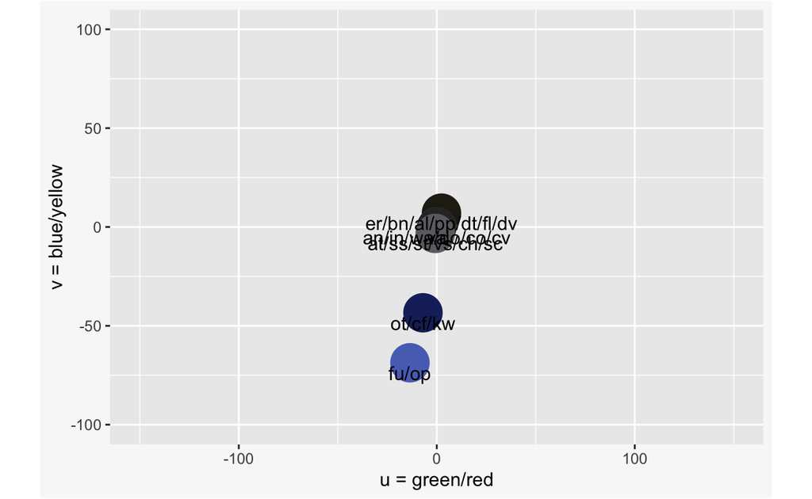

```
col4 %>%
  mutate(fg = prismatic::clr_deutan(fg)) %>%
  plot_uv()
```

```
# Might be better to just switch colours so that the most important
# colours are further apart - e.g. switch bn/fl/dv with dt
```

## Log changes

### Round 1, suggested by Hadley

op -> fu (operators to #4254A7 - cobalt)

pp -> dt (preprocessor to #aa5d00 - a11y chelsea gem)

do -> co (documentation to #545454 - a11y emporer)

cn -> fl (constant to #a1024a - magenta)

ss -> st (special string to #008000 - a11y japanese laurel)

er/al -> old cn (errors/alerts to #d91e18 - a11y thunderbird; functionally replace #ff0000 with #d91e18)

```
col4 %>% select(ends_with("2"), abbr)
```

```
# A tibble: 6 x 2
  fg_before2 abbr
  <chr>      <chr>
1 #9b1d3d    er/bn/al/pp/dt/fl/dv
2 #111111    va
3 #5E5E5E    an/in/wa/do/co/cv
4 #006C57    at/ss/st/vs/ch/sc
5 #006893    ot/cf/kw
6 #4758AB    fu/op
```

### Round 2, added by Alison

at -> st (attribute to #008000 - a11y japanese laurel)

```
col4 %>% select(ends_with("3"), abbr)
```

```
# A tibble: 6 x 2
  fg_before3 abbr
  <chr>      <chr>
1 #9b1d3d    er/bn/al/pp/dt/fl/dv
2 #111111    va
3 #5E5E5E    an/in/wa/do/co/cv
4 #006C57    at/ss/st/vs/ch/sc
5 #006893    ot/cf/kw
6 #4758AB    fu/op
```

### Round 3, added by Alison (again)

`#545454` -> `#5E5E5E` (an/in/wa/do/co/cv) [replace a11y emporer]

`#007faa` -> `#006893` (ot/cf/kw) [replace a11y deep cerulean]

`#d91e18` -> `#BD1600` (er/al) [replace a11y thunderbird]

`#008000` -> `#006E4C` (at/ss/st/vs/ch/sc) [replace a11y japanese laurel]

`#4254A7` -> `#4452C4` (fu/op) [not a11y]

`#19177c` -> `#??` (va) [not a11y]

`#4452C4` -> `#006893` (fu/op/ot/cf/kw)

`#BC1500` -> `#B12458` (er/al/pp/dt)

```
col4 %>% select(ends_with("4"), abbr)
```

```
# A tibble: 6 x 1
  abbr
  <chr>
1 er/bn/al/pp/dt/fl/dv
2 va
3 an/in/wa/do/co/cv
4 at/ss/st/vs/ch/sc
5 ot/cf/kw
6 fu/op
```

## ukekele moon :)

```
ukelele <- tribble(
  ~abbr, ~fg,
  "sky", "#0c2b85",
  "scarf", "#9b1d3d",
  "uke", "#328a75",
  "fox", "#c06b2e",
  "gray", "#727272",
  "teal", "#007faa"
  ) %>%
  # adjust luminance
  mutate(
    fg = ifelse(!abbr %in% c("sky", "scarf"),
                modify_hcl(fg, l = 40),
                fg),
    contrast = contrast_ratio(fg, bg)
  )

ukelele
```

```
# A tibble: 6 x 3
  abbr  fg      contrast
  <chr> <chr>      <dbl>
1 sky   #0c2b85    11.6
2 scarf #9b1d3d     7.50
3 uke   #006C57     6.02
4 fox   #994800     6.03
5 gray  #5E5E5E     6.11
6 teal  #006893     5.81
```

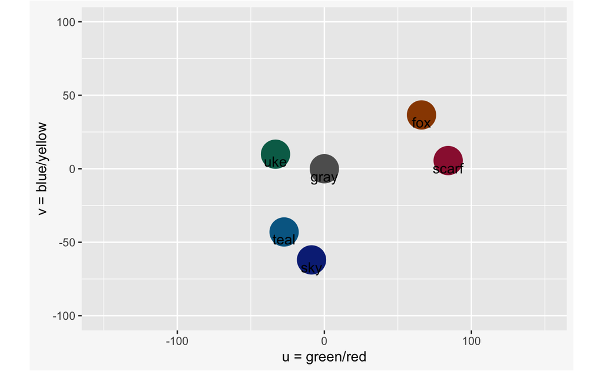

```
plot_uv(ukelele)
```

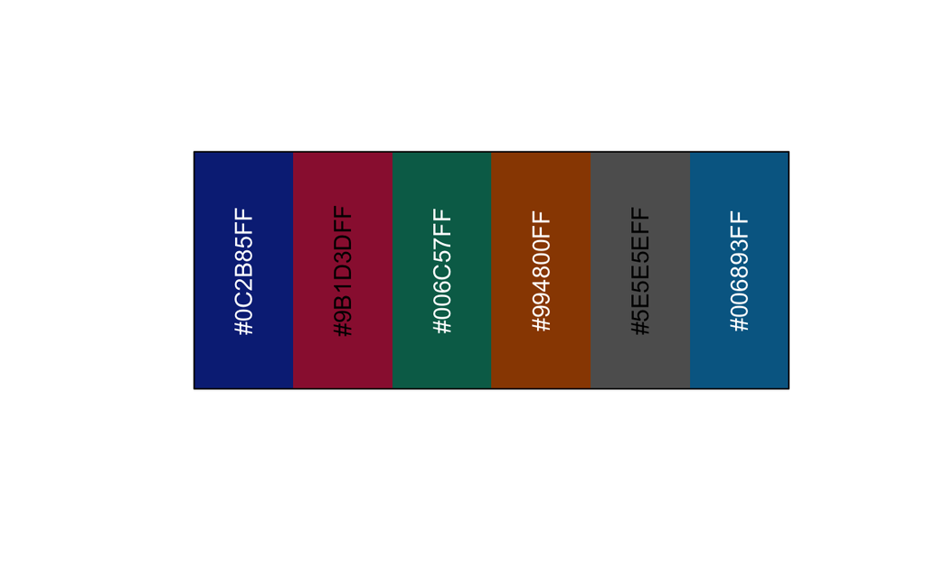

```
plot(prismatic::color(ukelele$fg), labels = TRUE)
```

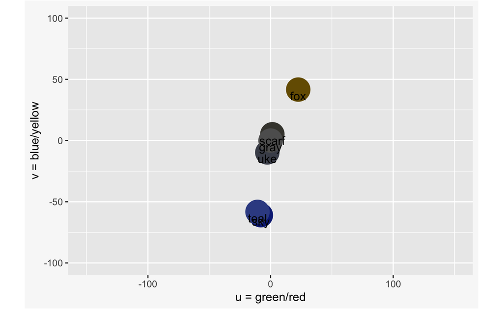

```
ukelele %>%
  mutate(fg = prismatic::clr_deutan(fg)) %>%
  plot_uv()
```

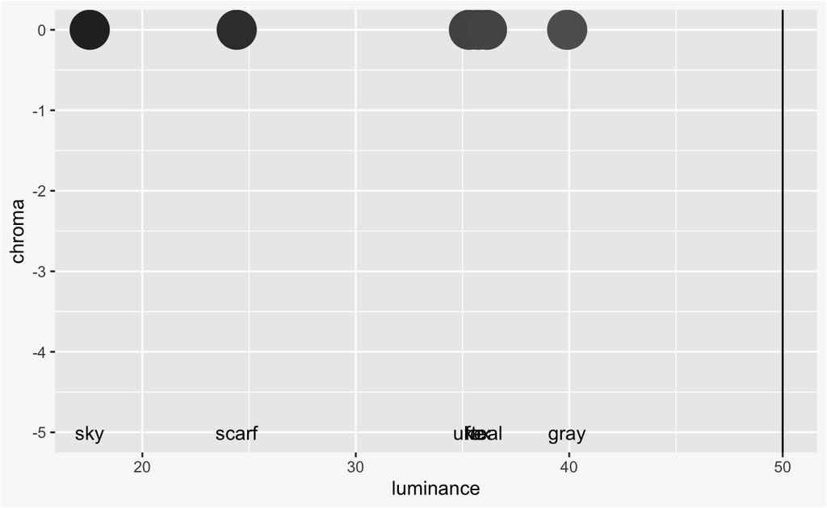

```
ukelele %>%
  mutate(fg = prismatic::clr_greyscale(fg)) %>%
  plot_cl()
```

green

#006C4A -> uke #006C57

#954a00 -> scarf #9b1d3d

#006893 -> kala #006D6F

#4452c4 -> sky #0c2b85

#5e5e5e -> gray #5E5E5E (don’t change!)

#111 -> fox #994800

v1 is distill original

v2 is Hadley edits

v3 is ukelele moon

v4 is variables = black like v2, keep fl = #9b1d3d, but split cn from #9b1d3d -> #994800

v5 is v4, but #0c2b85 -> #4758AB

```
modify_hcl("#4254a7", l = 40)
```

```
[1] "#4758AB"
```